# PepMapViz: A Versatile Toolkit for Peptide Mapping, Visualization, and Comparative Exploration

Zhenru Zhou zhou.zhenru@gene.com, Qui Phung phung.qui@gene.com, Corey Bakalarski bakalarski.corey@gene.com

# Introduction

This vignette demonstrates how to use `PepMapViz` with input files.

# Accessing Input Files

The input files are stored in the `inst/extdata/` directory of the package. You can access them using the `system.file()` function. The example files are searching results from PEAKS software. “Donor” column is added to plot peptides from different donors.

```r
library(PepMapViz)
```

```r
# Access the input files
input_file_folder <- system.file("extdata", package = "PepMapViz")

# Read the input files
resulting_df <- combine_files_from_folder(input_file_folder)
head(resulting_df)
```

```
##                   Peptide -10LgP      Mass Length Delta 1/k0   ppm      m/z
##                    <char>  <num>    <char>  <int>      <int> <num>    <num>
## 1: AAAFSEDC(+57.02)DSASTK  37.21 1458.5933     14          0   2.6 730.3126
## 2: AAAFSEDC(+57.02)DSASTK  33.42 1458.5933     14          0   2.6 730.3126
## 3: AAAFSEDC(+57.02)DSASTK  33.65 1458.5933     14          0   9.1 730.3174
## 4:           AADTAAQLTQRK  38.29 1272.6786     12          0   5.8 637.3562
## 5:        AADKFKEINNAHAIL  34.30 1653.8838     15          0   8.4 552.3116
## 6:        AADKFKEINNAHAIL  33.19 1653.8838     15          0   3.6 827.9599
##        z      RT    1/k0 Range     Area Intensity    Scan Precursor Id
##    <int>   <num>        <char>    <num>     <num>   <int>        <int>
## 1:     2 32.2605 0.9868-0.9969 1609.133  24479.44 1604441        59105
## 2:     2 32.2605 0.9876-0.9977 1609.133  24479.44 1606071        59211
## 3:     2 32.2096 0.9804-0.9904       NA        NA 1604457        59121
## 4:     2 59.7786 0.9932-1.0033 1404.297  18302.60 3041975       176855
## 5:     3 54.2409 0.8239-0.8340 7996.533 102527.84 2752258       150790
```

[output cut: 25 more lines]

# Strip the sequence

This function takes outputs from multiple platform, a data frame with a column containing peptide sequences with modifications and converts it into a new dataframe with plain peptide sequences without modifications.

```r
# Strip the sequence
striped_data_peaks <- strip_sequence(resulting_df, "Peptide", "Sequence", "PEAKS")
head(striped_data_peaks)
```

```
##                   Peptide -10LgP      Mass Length Delta 1/k0   ppm      m/z
##                    <char>  <num>    <char>  <int>      <int> <num>    <num>
## 1: AAAFSEDC(+57.02)DSASTK  37.21 1458.5933     14          0   2.6 730.3126
## 2: AAAFSEDC(+57.02)DSASTK  33.42 1458.5933     14          0   2.6 730.3126
## 3: AAAFSEDC(+57.02)DSASTK  33.65 1458.5933     14          0   9.1 730.3174
## 4:           AADTAAQLTQRK  38.29 1272.6786     12          0   5.8 637.3562
## 5:        AADKFKEINNAHAIL  34.30 1653.8838     15          0   8.4 552.3116
## 6:        AADKFKEINNAHAIL  33.19 1653.8838     15          0   3.6 827.9599
##        z      RT    1/k0 Range     Area Intensity    Scan Precursor Id
##    <int>   <num>        <char>    <num>     <num>   <int>        <int>
## 1:     2 32.2605 0.9868-0.9969 1609.133  24479.44 1604441        59105
## 2:     2 32.2605 0.9876-0.9977 1609.133  24479.44 1606071        59211
## 3:     2 32.2096 0.9804-0.9904       NA        NA 1604457        59121
## 4:     2 59.7786 0.9932-1.0033 1404.297  18302.60 3041975       176855
## 5:     3 54.2409 0.8239-0.8340 7996.533 102527.84 2752258       150790
```

[output cut: 25 more lines]

# Extract modifications information

This function takes outputs from multiple platform, a data frame with a column containing modified peptide sequence with the detailed post translational modification(PTM) information and converts it into a new dataframe with plain peptide sequences and associated PTM information.

```r
# Extract modifications information
PTM_table <- data.frame(PTM_mass = c("15.99", ".98", "57.02", "42.01"),
                        PTM_type = c("Ox", "Deamid", "Cam", "Acetyl"))
converted_data_peaks <- obtain_mod(
  striped_data_peaks,
  "Peptide",
  "PEAKS",
  strip_seq_col = NULL,
  PTM_table,
  PTM_annotation = TRUE,
  PTM_mass_column = "PTM_mass"
)
head(converted_data_peaks)
```

```
## Key: <PTM_mass>
##    PTM_mass PTM_position  reps         Peptide -10LgP      Mass Length
##      <char>        <num> <num>          <char>  <num>    <char>  <int>
## 1:     <NA>           NA     1    AADTAAQLTQRK  38.29 1272.6786     12
## 2:     <NA>           NA     1 AADKFKEINNAHAIL  34.30 1653.8838     15
## 3:     <NA>           NA     1 AADKFKEINNAHAIL  33.19 1653.8838     15
## 4:     <NA>           NA     1 AADKFKEINNAHAIL  34.18 1653.8838     15
## 5:     <NA>           NA     1  AAELRHVMTRLGEK  40.67 1609.8722     14
## 6:     <NA>           NA     1      AADTAAQITQ  25.77  988.4825     10
##    Delta 1/k0   ppm      m/z     z      RT    1/k0 Range      Area  Intensity
##         <int> <num>    <num> <int>   <num>        <char>     <num>      <num>
## 1:          0   5.8 637.3562     2 59.7786 0.9932-1.0033 1404.2975  18302.596
## 2:          0   8.4 552.3116     3 54.2409 0.8239-0.8340 7996.5327 102527.836
## 3:          0   3.6 827.9599     2 54.2391 1.1180-1.1281  715.1580  12307.447
## 4:          0   8.4 552.3116     3 54.2409 0.8288-0.8389 7996.5327 102527.836
```

[output cut: 34 more lines]

# Match peptide sequence with provided sequence and calculate positions

This function matches peptide sequences from the ‘peptide_data’ data frame to corresponding provided whole sequences in the ‘whole_seq’ data frame. It calculates the start and end positions of the matched sequences and returns data frame with information about the matching positions.

```r
# Match peptide sequence with provided sequence and calculate positions
whole_seq <- data.frame(
  Epitope = c("Boco", "Boco"),
  Chain = c("HC", "LC"),
  Region_Sequence = c("QVQLVQSGAEVKKPGASVKVSCKASGYTFTSYYMHWVRQAPGQGLEWMGEISPFGGRTNY…",
                      "DIQMTQSPSSLSASVGDRVTITCRASQGISSALAWYQQKPGKAPKLLIYSASYRYTGVPS…"
  )
)
matching_result <- match_and_calculate_positions(
  converted_data_peaks,
  'Sequence',
  whole_seq,
  match_columns = NULL,
  sequence_length = c(10, 30),
  column_keep = c(
    "PTM_mass",
    "PTM_position",
    "reps",
    "Area",
    "Donor",
    "PTM_type"
  )
)
head(matching_result)
```

```
##             Sequence PTM_mass PTM_position reps     Area Donor PTM_type Epitope
## 315  AKVQWKVDNALQSGN     <NA>         <NA>    1 1093.797    D1     <NA>    Boco
## 316   AKVQWKVDNALQSG     <NA>         <NA>    1     <NA>    D1     <NA>    Boco
## 317 AKVQWKVDNALQSGNS     <NA>         <NA>    1 32295.91    D1     <NA>    Boco
## 318 AKVQWKVDNALQSGNS     <NA>         <NA>    1 32295.91    D1     <NA>    Boco
## 319 AKVQWKVDNALQSGNS     <NA>         <NA>    1 32295.91    D1     <NA>    Boco
## 320 AKVQWKVDNALQSGNS     <NA>         <NA>    1 32295.91    D1     <NA>    Boco
##     Chain Start_Position End_Position
## 315    LC            144          158
## 316    LC            144          157
## 317    LC            144          159
## 318    LC            144          159
## 319    LC            144          159
## 320    LC            144          159
```

# Quantify matched peptide sequences

This function takes peptide matching result and quantifies the matched peptide sequences based on the provided quantification method. If the quantification method is ‘PSM’, the function calculates the number of matched peptide sequences in each positions of the provided whole sequence. If the quantification method is ‘Area’, the function select the max value in area column of identical peptide sequences and calculates the sum of the areas of the matched peptide sequences in each positions of the provided whole sequence.

```r
# Quantify matched peptide sequences by PSM
matching_columns = c("Chain", "Epitope")
distinct_columns = c("Donor")
data_with_psm <- peptide_quantification(
  whole_seq,
  matching_result,
  matching_columns,
  distinct_columns,
  quantify_method = "PSM",
  with_PTM = TRUE,
  reps = TRUE
)
region <- data.frame(
  Epitope = c("Boco", "Boco", "Boco", "Boco", "Boco", "Boco"),
  Chain = c("HC", "HC", "HC", "HC", "LC", "LC"),
  Region = c("VH", "CH1", "CH2", "CH3", "VL", "CL"),
  Region_start = c(1,119,229,338,1,108),
  Region_end = c(118,228,337,444,107,214)
)
result_with_psm <- data.frame()
for (i in 1:nrow(region)) {
  chain <- region$Chain[i]
  region_start <- region$Region_start[i]
  region_end <- region$Region_end[i]
  region_name <- region$Region[i]

  temp <- data_with_psm[data_with_psm$Chain == chain &
                          data_with_psm$Position >= region_start &
                          data_with_psm$Position <= region_end, ]
  temp$Region <- region_name

  result_with_psm <- rbind(result_with_psm, temp)
}

head(result_with_psm)
```

```
##   Character Position Chain Epitope PSM Donor   PTM PTM_type Region
## 1         Q        1    HC    Boco   0    D1 FALSE     <NA>     VH
## 2         V        2    HC    Boco   0    D1 FALSE     <NA>     VH
## 3         Q        3    HC    Boco   0    D1 FALSE     <NA>     VH
## 4         L        4    HC    Boco   0    D1 FALSE     <NA>     VH
## 5         V        5    HC    Boco   0    D1 FALSE     <NA>     VH
## 6         Q        6    HC    Boco   0    D1 FALSE     <NA>     VH
```

# Plotting peptide in whole provided sequence

This function takes the quantified peptide data frame and plots the matched peptide sequences in the provided whole sequence. The function returns a ggplot object with the matched peptide sequences plotted in the provided whole sequence.

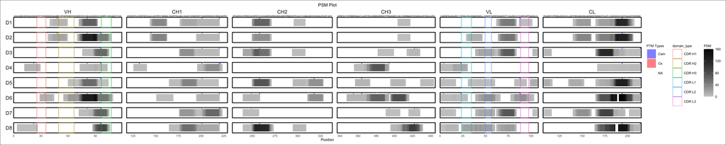

```r
# Plotting peptide in whole provided sequence
domain <- data.frame(
  domain_type = c("CDR H1", "CDR H2", "CDR H3", "CDR L1", "CDR L2", "CDR L3"),
  Region = c("VH", "VH", "VH",  "VL", "VL", "VL"),
  Epitope = c("Boco", "Boco", "Boco", "Boco", "Boco", "Boco"),
  domain_start = c(26, 50, 97,  24, 50, 89),
  domain_end = c(35, 66, 107,  34, 56, 97)
)
x_axis_vars <- c("Region")
y_axis_vars <- c("Donor")
column_order <- list(
    Donor = "D1,D2,D3,D4,D5,D6,D7,D8",
    Region = "VH,CH1,CH2,CH3,VL,CL"
)
domain_color <- c(
"CDR H1" = "#F8766D",
"CDR H2" = "#B79F00",
"CDR H3" = "#00BA38",
"CDR L1" = "#00BFC4",
"CDR L2" = "#619CFF",
"CDR L3" = "#F564E3"
)
PTM_color <- c(
  "Ox" = "red",
  "Deamid" = "cyan",
  "Cam" = "blue",
  "Acetyl" = "magenta"
)
label_value = list(Donor = "D1")
p_psm <- create_peptide_plot(
  result_with_psm,
  y_axis_vars,
  x_axis_vars,
  y_expand = c(0.2, 0.2),
  x_expand = c(0.5, 0.5),
  theme_options = list(legend.box = "horizontal"),
  labs_options = list(title = "PSM Plot", x = "Position", fill = "PSM"),
  color_fill_column = 'PSM',
  fill_gradient_options = list(limits = c(0, 160)),  # Set the limits for the color scale
  label_size = 1.9,
  add_domain = TRUE,
  domain = domain,
  domain_start_column = "domain_start",
  domain_end_column = "domain_end",
  domain_type_column = "domain_type",
  domain_color = domain_color,
  PTM = TRUE,
  PTM_type_column = "PTM_type",
  PTM_color = PTM_color,
  add_label = TRUE,
  label_column = "Character",
  label_value = label_value,
  column_order = column_order
)
print(p_psm)
```